# 概述

#### 11. 样本大部分分布在硫酸盐低浓度区域；硫酸盐含量与品质呈正相关性，品质越高硫酸盐含量越高。

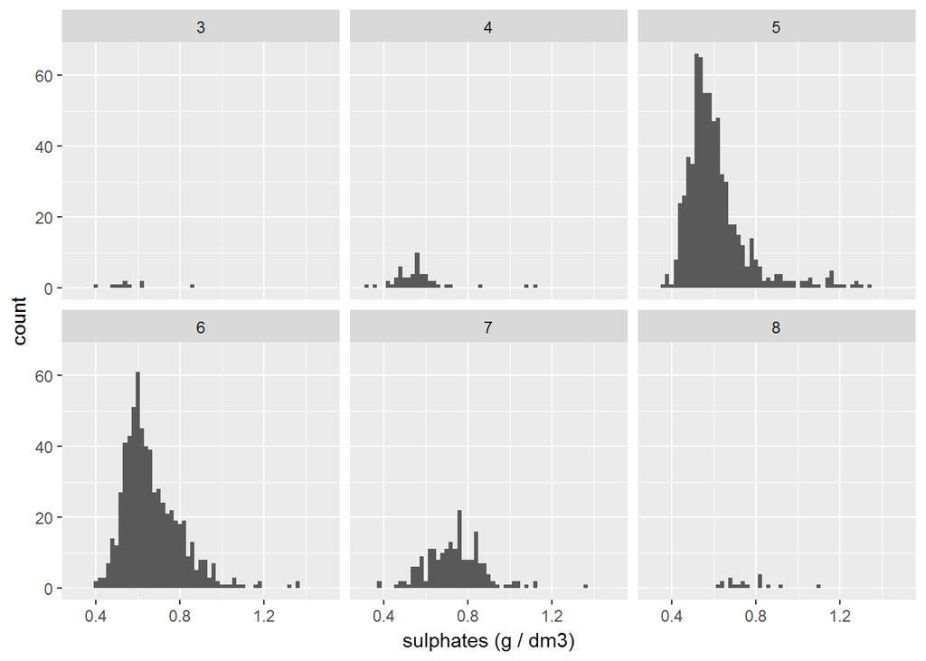

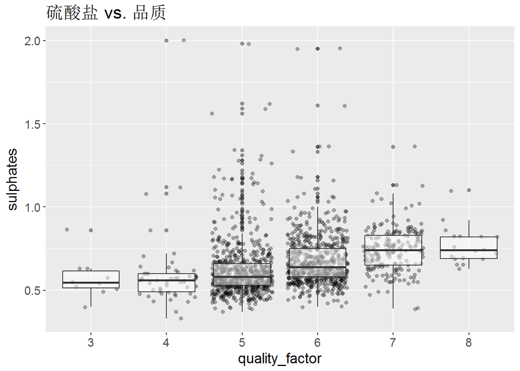

#### 12. 酒精度与品质之间基本上呈正相关性，但品质为5的均值低于4和6，其他样本均值呈上升趋势。

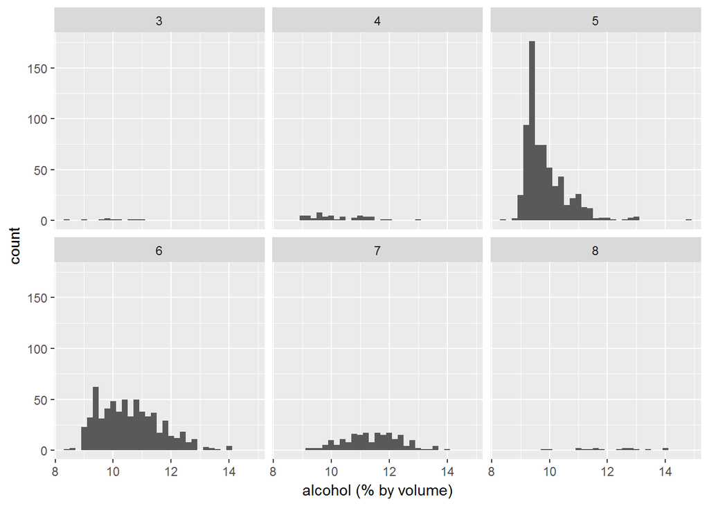

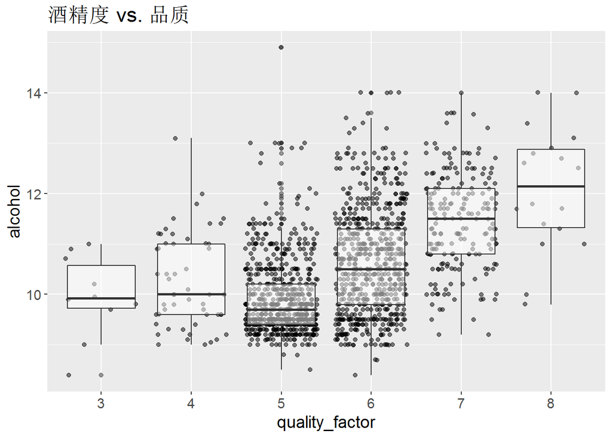

# 第四部分 双变量分析

### 1. Talk about some of the relationships you observed in this part of the investigation. How did the feature(s) of interest vary with other features in the dataset?

#### 通过观察每个变量与品质变量之间的boxplot关系发现，酒的品质越高，volatile.acidity（挥发性酸）均值越低，citric acid(柠檬酸)均值越来越高，density(密度)均值也是基本上呈下降趋势，pH值均值也呈略微下降趋势，sulphates(硫酸盐)均值呈上升趋势，alcohol(酒精度)均值上升

### 2. Did you observe any interesting relationships between the other features (not the main feature(s) of interest)?

#### 变量total.sulfur.dioxide和free.sulfur.dioxide之间呈正相关性；total.sulfur.dioxide和free.sulfur.dioxide与酒的品质呈先上升后下降趋势，可能存在高次相关性。

### 3. What was the strongest relationship you found?

#### 酒精度与酒的品质的相关度最大;total.sulfur.dioxide与free.sulfur.dioxide相关系数最高。

# 第五部分 多变量图

#### 1. 从下图可以看出fixed.acidity与density之间相互增强，为了扩大区分度，将density变量取平方，从线性拟合图可以看出酒品质越高，线性拟合越靠下，说明这两种成分的含量可以区分酒的品质。

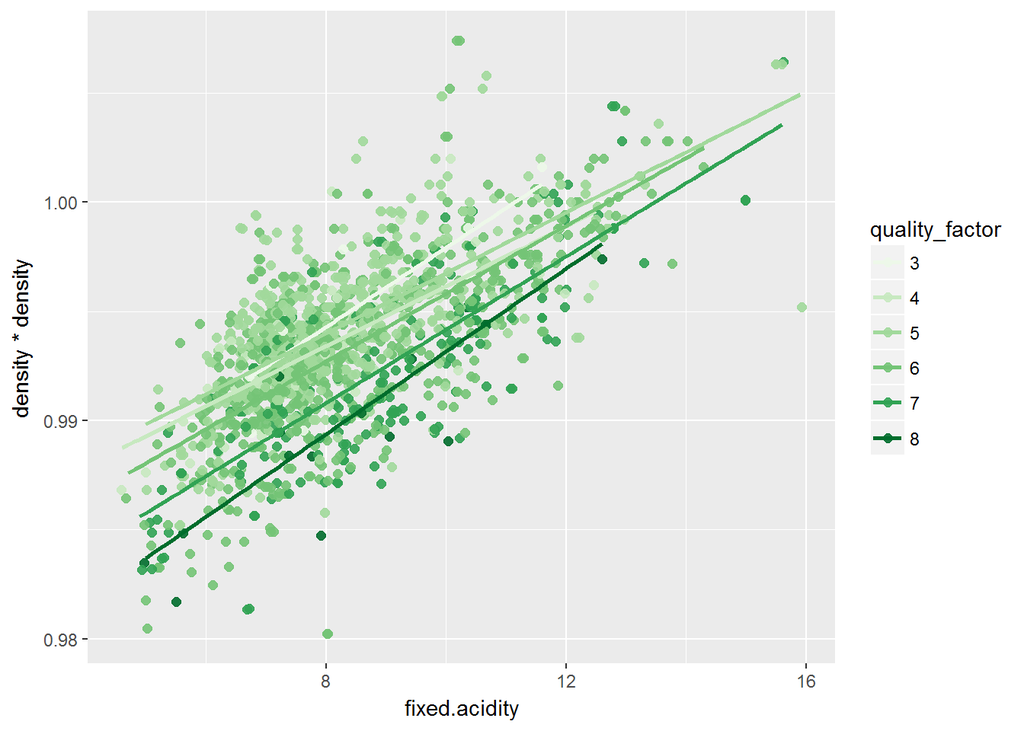

```r
# fixed.acidity vs. density^2 vs. quality
ggplot(data=subset(winedata,total.sulfur.dioxide<200),
       aes(x=fixed.acidity,y=density*density,color=quality_factor))+
    geom_point(alpha = 0.9, size = 2, position = 'jitter')+
    geom_smooth(method = 'lm',se=FALSE,size=1)+
  scale_color_brewer(palette = 'Greens')
```

```r
    ggtitle('fixed.acidity vs. density vs. quality')
```

```
## $title
## [1] "fixed.acidity vs. density vs. quality"
##
## $subtitle
## NULL
##
## attr(,"class")
## [1] "labels"
```

#### 2. 从下图可以看出酒精度和密度之间呈下降趋势，但是线性拟合曲线相互重叠，并不能区分酒的品质。

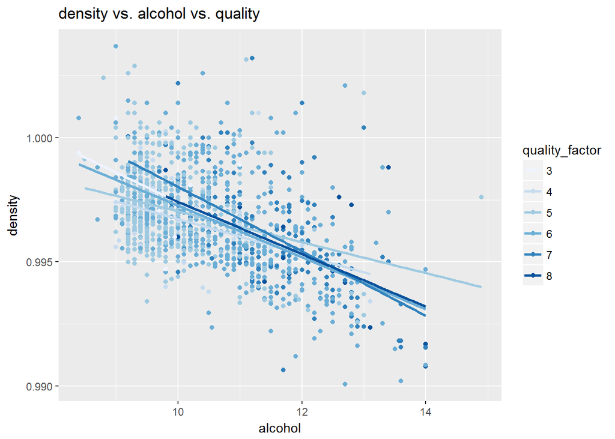

### 决策树

```
## n= 1599
##
## node), split, n, loss, yval, (yprob)
##       * denotes terminal node
##
##  1) root 1599 918 5 (0.0063 0.033 0.43 0.4 0.12 0.011)
##    2) alcohol< 10.25 842 323 5 (0.0083 0.034 0.62 0.31 0.03 0.0024)
##      4) sulphates< 0.575 353  91 5 (0.011 0.054 0.74 0.19 0.0057 0) *
##      5) sulphates>=0.575 489 232 5 (0.0061 0.02 0.53 0.4 0.047 0.0041)
##       10) volatile.acidity>=0.3175 443 193 5 (0.0068 0.023 0.56 0.37 0.034 0.0023) *
##       11) volatile.acidity< 0.3175 46  16 6 (0 0 0.15 0.65 0.17 0.022) *
##    3) alcohol>=10.25 757 379 6 (0.004 0.032 0.21 0.5 0.23 0.021)
##      6) alcohol< 11.55 507 248 6 (0.0059 0.041 0.28 0.51 0.15 0.0079)
##       12) volatile.acidity>=0.375 375 171 6 (0.008 0.053 0.31 0.54 0.077 0.0027)
##         24) sulphates< 0.585 123  67 5 (0.024 0.11 0.46 0.37 0.041 0) *
##         25) sulphates>=0.585 252  93 6 (0 0.024 0.25 0.63 0.095 0.004) *
##       13) volatile.acidity< 0.375 132  77 6 (0 0.0076 0.2 0.42 0.36 0.023)
##         26) pH>=3.265 75  38 6 (0 0.013 0.27 0.49 0.23 0) *
##         27) pH< 3.265 57  27 7 (0 0 0.11 0.32 0.53 0.053) *
##      7) alcohol>=11.55 250 131 6 (0 0.012 0.072 0.48 0.39 0.048)
##       14) sulphates< 0.685 136  53 6 (0 0.022 0.11 0.61 0.25 0.0074) *
##       15) sulphates>=0.685 114  50 7 (0 0 0.026 0.32 0.56 0.096) *
```

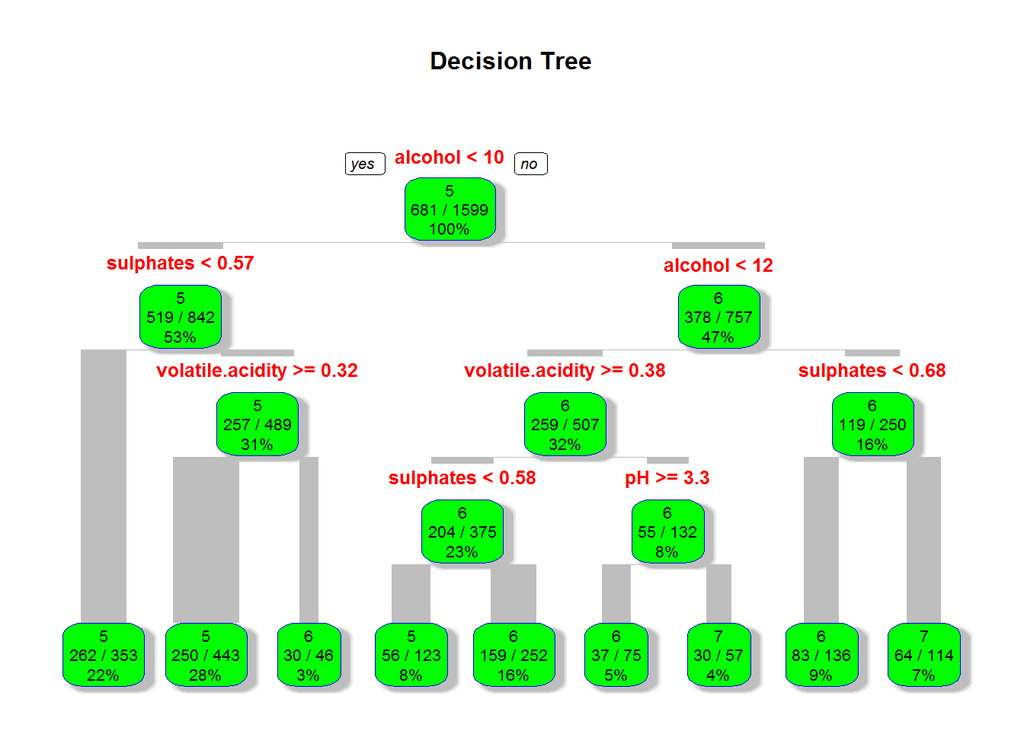

# 第六部分 多变量分析

### 1. Talk about some of the relationships you observed in this part of the investigation. Were there features that strengthened each other in terms of looking at your feature(s) of interest?

#### fixed.acidity与density之间相互增强；

### 2. Were there any interesting or surprising interactions between features?

#### alcohol与density之间相互减弱，从物理的角度可以解释这个原因，酒精的密度比水低，酒精含量越高酒的密度就越低。

### OPTIONAL: Did you create any models with your dataset? Discuss the strengths and limitations of your model.

#### 尝试使用决策树建模，但是结果只能区分出5，6，7三种酒，其他的品质的酒区分不明显

# 第七部分 最终图和总结

### 图一

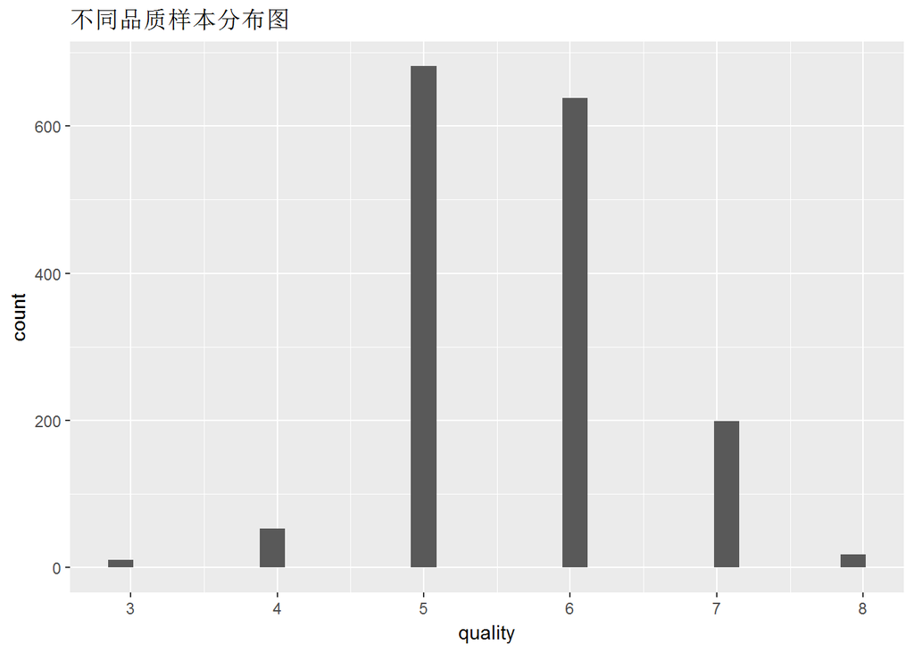

```r
qplot(data=winedata,x=quality)+
  ggtitle('不同品质样本分布图')
```

### 描述一

#### 通过对单quality单一变量的分析看出样本分布不均匀，5、6样本量总和超过总样本80%，为后续分析数据带来不利因素。

### 图二

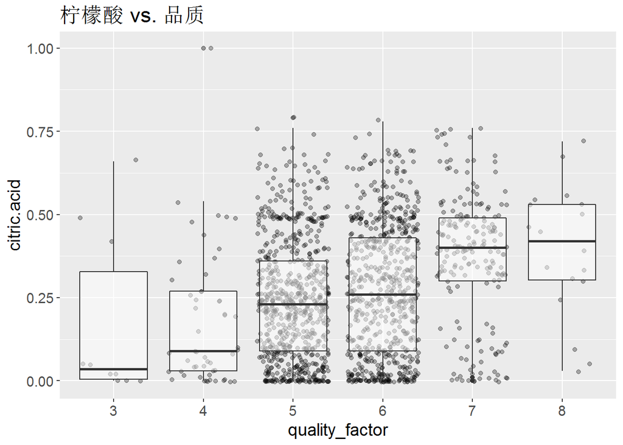

```r
ggplot(aes(x=quality_factor,y=citric.acid),data=subset(winedata,total.sulfur.dioxide<200))+
  geom_jitter(alpha=0.3)+
  geom_boxplot(alpha=0.5)+
  ggtitle('柠檬酸 vs. 品质')+
  theme(text=element_text(family="STKaiti",size=14))
```

### 描述二

#### 通过其他变量与酒的品质变量之间的boxplot可以看出一些变量的均值与品质之间存在很强的相关性，比如citric.acid变量均值与品质之间存在正相关性，酒的品质越高citric.acid含量越高。

### 图三

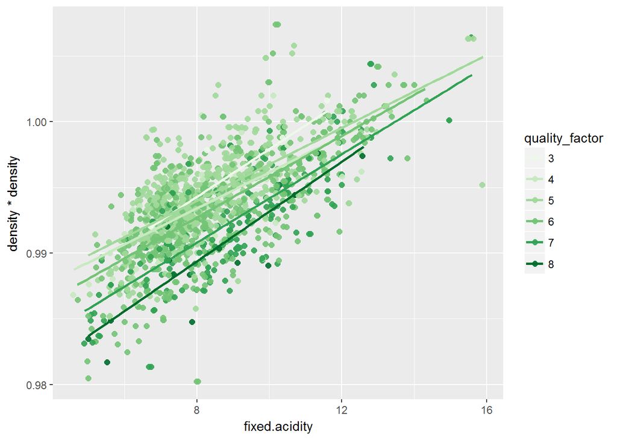

```r
# fixed.acidity vs. density^2 vs. quality
ggplot(data=subset(winedata,total.sulfur.dioxide<200),
       aes(x=fixed.acidity,y=density*density,color=quality_factor))+
    geom_point(alpha = 0.9, size = 2, position = 'jitter')+
    geom_smooth(method = 'lm',se=FALSE,size=1)+
  scale_color_brewer(palette = 'Greens')
```

```r
    ggtitle('fixed.acidity vs. density vs. quality')
```

```
## $title
## [1] "fixed.acidity vs. density vs. quality"
##
## $subtitle
## NULL
##
## attr(,"class")
## [1] "labels"
```

# 第八部分 反思

## 遇到的问题

#### 1.数据量小且数据分布不均匀，品质为5和6的样本占比超过80%，占比过大；

#### 2.特征变量与特征变量之间，特征变量与目标变量之间的相关性很低，只有大概的趋势，很难通过取对数或者其他变换方式得到很明显的相关趋势。

#### 3.这些酒的品质是品酒师通过嗅觉和味觉给出的判断，带有一定的主观性，可能会给目标变量带来一定的干扰；

#### 4.酒的化学成分在一定程度上决定了酒的口感，但是所有这些化学成分的配比才是决定口感的更重要因素。

## 以后改进的方向

#### 1.增大样本总量，通过分层抽样方式使数据均匀分布。

#### 2.使用更多变量，也许会找出相关性更高的变量。